# Contribution of countries in CO<sub>2</sub> emission and death due to air pollution

Amir TALEBI

09 September, 2023

# ABSTRACT:

### We have studied the contribution of countries in CO<sub>2</sub> emission from 1990 to 2019. Additionally, the death rate due to total air pollution factor has been studied. Overally, death rate due to total air contamination (including indoor air pollution, Outdoor particulate matter and Outdoor ozone pollution) has decreased during the years. However, based on this data-set the global CO<sub>2</sub> emission has been fluctuating, and is not decreasing monotonically. Our linear fit model predicts a negative rate for the number of death until 2022 (Without including the effect of Covid 19). Finally, based on the results, eastern European countries show a higher rate of death as a consequence of total air pollution.

### Libraries:

```r
library(tidyverse)
library(highcharter)
library(forecast)
library(dplyr)
library(rmarkdown)
library(cowplot)
```

### Corresponding data for this project are as follows:

- [CO<sub>2</sub> emissions around the world](https://www.kaggle.com/datasets/koustavghosh149/co2-emission-around-the-world)
- [Death due to air pollution](https://www.kaggle.com/datasets/akshat0giri/death-due-to-air-pollution-19902017)

### What is metric ton per capita:

- 1 metric ton = 1,000 kilograms
- CO<sub>2</sub> emission per capita is measured as the total amount of carbon dioxide emitted by a country as a consequence of all relevant human activities (production and consumption), divided by the population of that country.

```r
# to create a pageable table
paged_table(co2_emission, options = list(rows.print = 7, cols.print = 5))
```

| Country | country_code | Region | Indicator.Name | X1990 | X1991 | X1992 | X1993 | X1994 | X1995 | X1996 | X1997 | X1998 | X1999 | X2000 | X2001 | X2002 | X2003 | X2004 | X2005 | X2006 | X2007 | X2008 | X2009 | X2010 | X2011 | X2012 | X2013 | X2014 | X2015 | … |
| --- | --- | --- | --- | --- | --- | --- | --- | --- | --- | --- | --- | --- | --- | --- | --- | --- | --- | --- | --- | --- | --- | --- | --- | --- | --- | --- | --- | --- | --- | --- |
| Aruba | ABW | Latin America & Caribbean | CO2 emissions (metric tons per capita) | NA | NA | NA | NA | NA | NA | NA | NA | NA | NA | NA | NA | NA | NA | NA | NA | NA | NA | NA | NA | NA | NA | NA | NA | NA | NA | … |
| Afghanistan | AFG | South Asia | CO2 emissions (metric tons per capita) | 0.191745115 | 0.167681579 | 0.095957742 | 0.084721110 | 0.07554583 | 0.068467956 | 0.06258803 | 0.056826618 | 0.05269086 | 0.04015697 | 0.03657370 | 0.03378536 | 0.04557366 | 0.05151838 | 0.04165539 | 0.06041878 | 0.06658329 | 0.06531235 | 0.12841656 | 0.17186242 | 0.24361404 | 0.29650624 | 0.25929533 | 0.18562366 | 0.14623562 | 0.17289674 | … |
| Angola | AGO | Sub-Saharan Africa | CO2 emissions (metric tons per capita) | 0.553661955 | 0.544538649 | 0.543557223 | 0.708984230 | 0.83680440 | 0.912141485 | 1.07216847 | 1.086636974 | 1.09182531 | 1.10985966 | 0.98807738 | 0.94182891 | 0.89557767 | 0.92486944 | 0.93026295 | 0.81353929 | 0.82184008 | 0.81175351 | 0.88865801 | 0.93940398 | 0.97618420 | 0.98552231 | 0.95069588 | 1.03629385 | 1.09977911 | 1.13504405 | … |
| Albania | ALB | Europe & Central Asia | CO2 emissions (metric tons per capita) | 1.819541634 | 1.242810220 | 0.683699826 | 0.638307036 | 0.64535519 | 0.605436253 | 0.61236736 | 0.466921472 | 0.57215370 | 0.95535931 | 1.02621311 | 1.05549588 | 1.23237878 | 1.33898498 | 1.40405869 | 1.33820940 | 1.33999574 | 1.39393137 | 1.38431125 | 1.44149356 | 1.52762366 | 1.66942319 | 1.50324046 | 1.53363004 | 1.66833737 | 1.60377515 | … |
| Andorra | AND | Europe & Central Asia | CO2 emissions (metric tons per capita) | 7.521831658 | 7.235379240 | 6.963078700 | 6.724177518 | 6.54157891 | 6.733479486 | 6.99159455 | 7.307441152 | 7.63953851 | 7.92319165 | 7.95228628 | 7.72154906 | 7.56623988 | 7.24241557 | 7.34426233 | 7.35378001 | 6.79054277 | 6.53104692 | 6.43930386 | 6.15668748 | 6.15719778 | 5.85088610 | 5.94465417 | 5.94280041 | 5.80712772 | 6.02618182 | … |
| United Arab Emirates | ARE | Middle East & North Africa | CO2 emissions (metric tons per capita) | 30.195188570 | 31.778496240 | 29.080925840 | 29.275677770 | 30.84933296 | 31.125018060 | 30.92802588 | 30.486332620 | 29.66358052 | 28.88710798 | 27.03515911 | 29.43026994 | 28.50146173 | 27.96926982 | 27.03893822 | 25.38238104 | 22.93510429 | 21.37028576 | 22.01146924 | 19.83234887 | 19.03976975 | 18.50945738 | 19.20780112 | 20.05564757 | 20.05169797 | 21.07764197 | … |
| Argentina | ARG | Latin America & Caribbean | CO2 emissions (metric tons per capita) | 3.075541328 | 3.202031307 | 3.218973722 | 3.245795281 | 3.25294529 | 3.241341893 | 3.47695321 | 3.536989954 | 3.67879380 | 3.68851827 | 3.58739204 | 3.36037118 | 3.11742483 | 3.35172371 | 3.67297400 | 3.75363924 | 3.94249129 | 4.10262964 | 4.17238853 | 3.86756997 | 4.09968971 | 4.28098935 | 4.26422378 | 4.34211507 | 4.20909563 | 4.30191388 | … |
| Armenia | ARM | Europe & Central Asia | CO2 emissions (metric tons per capita) | 5.610254358 | 5.902576393 | 3.166009260 | 1.498612445 | 0.83443373 | 1.090960291 | 0.81433919 | 1.066043297 | 1.11622545 | 1.00679180 | 1.15976136 | 1.18006245 | 1.02835352 | 1.15973224 | 1.25303469 | 1.49601076 | 1.51776299 | 1.77316143 | 1.95693036 | 1.56158360 | 1.50835124 | 1.71734338 | 1.98319203 | 1.89812717 | 1.88160774 | 1.82529224 | … |
| American Samoa | ASM | East Asia & Pacific | CO2 emissions (metric tons per capita) | NA | NA | NA | NA | NA | NA | NA | NA | NA | NA | NA | NA | NA | NA | NA | NA | NA | NA | NA | NA | NA | NA | NA | NA | NA | NA | … |
| Antigua and Barbuda | ATG | Latin America & Caribbean | CO2 emissions (metric tons per capita) | 3.358226856 | 3.472057826 | 4.498983850 | 3.800720617 | 3.72018273 | 3.931733458 | 3.98996808 | 4.044235570 | 4.37045029 | 4.41920883 | 4.34170537 | 4.53297415 | 4.98096996 | 5.16952247 | 4.97840624 | 5.03302149 | 5.31947044 | 5.47430064 | 5.62100369 | 16.02434762 | 5.56628433 | 6.05042041 | 7.74276315 | 5.13605069 | 5.18571324 | 5.23666531 | … |

[output cut: 205 more lines]

```r
paged_table(death_airPolution, options = list(rows.print = 7, cols.print = 5))
```

| Country | Code | Year | Air.pollution..total...deaths.per.100.000. | Indoor.air.pollution..deaths.per.100.000. | Outdoor.particulate.matter..deaths.per.100.000. | Outdoor.ozone.pollution..deaths.per.100.000. |
| --- | --- | --- | --- | --- | --- | --- |
| Afghanistan | AFG | 1990 | 299.47731 | 250.36290970 | 46.446589 | 5.616442031 |
| Afghanistan | AFG | 1991 | 291.27797 | 242.57512500 | 46.033841 | 5.603960116 |
| Afghanistan | AFG | 1992 | 278.96306 | 232.04387790 | 44.243766 | 5.611822065 |
| Afghanistan | AFG | 1993 | 278.79081 | 231.64813350 | 44.440148 | 5.655266063 |
| Afghanistan | AFG | 1994 | 287.16292 | 238.83717680 | 45.594328 | 5.718922221 |
| Afghanistan | AFG | 1995 | 288.01422 | 239.90659870 | 45.367141 | 5.739173782 |
| Afghanistan | AFG | 1996 | 286.64259 | 238.51205050 | 45.383591 | 5.747049995 |
| Afghanistan | AFG | 1997 | 286.44745 | 238.11351990 | 45.585062 | 5.755508661 |
| Afghanistan | AFG | 1998 | 286.26520 | 238.68015020 | 44.837490 | 5.758544580 |
| Afghanistan | AFG | 1999 | 286.63602 | 238.53929410 | 45.325501 | 5.793572911 |

[output cut: 990 more lines]

# Visualization of our data

```r
df1 <- aggregate(death_airPolution["Air.pollution..total...deaths.per.100.000."], by=death_airPolution["Year"], sum)
data_without_na <- replace(co2_emission, is.na(co2_emission), 0)
df2 <- data_without_na |>
  select(starts_with("X"))
totEmission <- colSums(df2)
trial_df2 <- as.data.frame(totEmission)
data_new2 <- slice(trial_df2, 1:(n() - 2))                    # to drop 2018 and 2019 rows.
data_new3 <- rownames_to_column(data_new2, var = "Year")
data_new3$Year<-gsub("X","",as.character(data_new3$Year))     # to get rid of "X" in the beginning of Year column.
total <- merge(data_new3, df1, by="Year")                     # Finally, this will merge two data sets.
colnames(total)[3] <- "totAirPollt"

hc <- highchart() |>
        hc_yAxis_multiples(
        list(
          title=list(text="CO2 emissions (metric ton per capita)"), lineWidth = 3, opposite = FALSE),
          list(
        title=list(text="Total death due to air pollution"), lineWidth = 3, opposite = TRUE)
        ) |>
        hc_xAxis(
        categories = total$Year, labels = list(rotation = -60, style = list(fontSize = "1.4vh")),
        plotBands = list(list(color = "#ffcccb", from = 3, to = 5, label = list(text = "")))
        ) |>
        hc_add_series(
          data = total$totEmission, yAxis = 0, name = "Total CO<sub>2</sub> emission", color = '#fbb339'
            ) |>
        hc_add_series(
          data = total$totAirPollt,  color = "#2e6844", yAxis = 1, name = "Total death due to air Pollution"
          ) |>
        hc_title(text = "Dual y-axis chart")
hc
```

[interactive chart not shown]

Fig. (1): Global CO<sub>2</sub> emission and death rate from 1990-2017

### Based on data the global rate of death due to air pollution (total deaths per 100,000) has been decreasing, Fig. (1). Additionally, total CO<sub>2</sub> does not follow a monotonic trend and during last three decades has been oscillating. As the shaded area shows, the amount of [Carbon Dioxide emission dropped in 1990 decade](https://www.nytimes.com/1991/12/08/world/carbon-dioxide-emissions-dropped-in-1990-ecologists-say.html), reaching to a minimum at 1994. The reason is attributed to a sharp collapse in fuel use and economies of Soviet Union and countries in Eastern Europe.

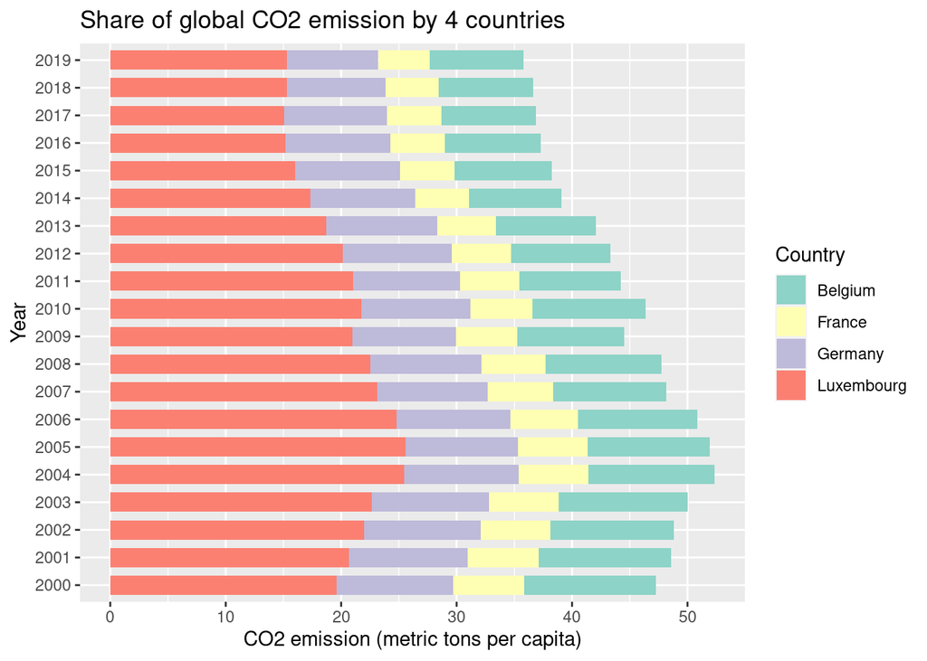

Fig. (2): Comparative study of Carbon-dioxide emission among four countries

```r
df = subset(co2_emission, select = -c(country_code, Indicator.Name))
na.omit(df) |>
  pivot_longer(cols = -c('Country', 'Region'), names_to = "Year", values_to = 'co2_Capita') -> dflonger
dflonger$Year<-gsub("X","", as.character(dflonger$Year))

data_new <- dflonger |>
  filter(
    Country %in% c("France", "Germany", "Luxembourg", "Belgium"),
    Year >= 2000  , Year <= 2019
    ) |>
    select(Year, Country, co2_Capita)

ggplot(data_new, aes(x = co2_Capita, y = Year, fill = Country)) +
  geom_bar(stat = "identity", width = 0.7) +
  labs(
    title = "Share of global CO2 emission by 4 countries",
    x = "CO2 emission (metric tons per capita)"
    ) +
  scale_fill_brewer(palette = "Set3")
```

### We have narrowed down our analysis of CO<sub>2</sub> emission to four neighboring countries. Among all these years, Luxembourg had the most contribution in CO<sub>2</sub> emission. The country is still far from reaching its contribution for the reducing of greenhouse gas emissions, [based on the news](https://today.rtl.lu/news/luxembourg/a/1184731.html). This is mostly owing to petrol and fuel tourism in the country.

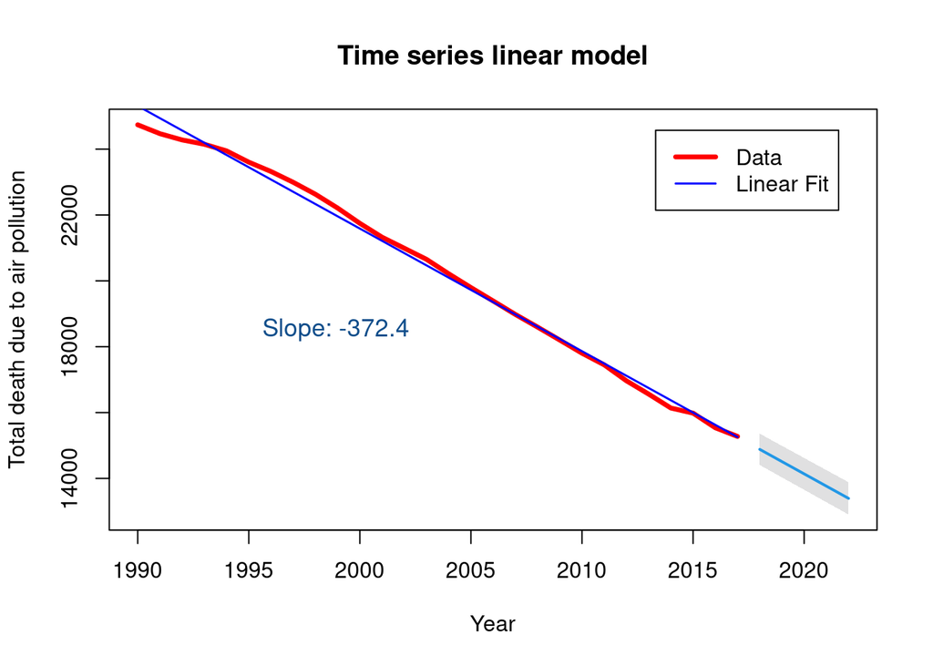

Fig. (3): Linear fit and prediction for next 5 years

```r
death_airPolution |>
  group_by(Year) |>
  summarise(total = sum(Air.pollution..total...deaths.per.100.000.)) -> tot1
GData <- ts(tot1[,2], start = 1990, end = 2017, frequency = 1)
modeel<- tslm (GData~trend)
fcast <- forecast (modeel, h=5, level = c(8,95))
plot (
  fcast, xlab ="Year", ylab ="Total death due to air pollution", main ="Time series linear model",
 col.main ="black", col = 'red' , lwd=3.5
 )
lines (fitted (modeel), col = 'blue', lwd=1.5)
legend(
  'topright',inset=0.05,c("Data","Linear Fit"),lty=1,col=c("red","blue"), lwd=c(3.5,1.5)
  )
text(1995, 18500, labels = "Slope: -372.4", pos = 4, cex = 1.1, col = "dodgerblue4")
```

### For the sake of completeness, we have made a time-series linear model fit to our data for the death rate due to total air pollutants. Based on the model, the trend continues with the same negative rate until 2022.

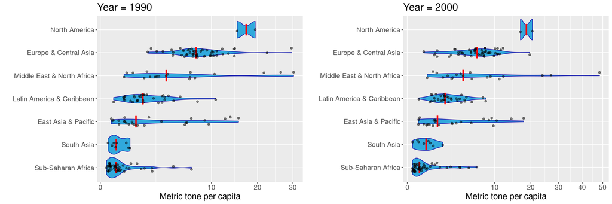

Fig. (4): Violin plots panel for the total CO<sub>2</sub> emission at 1990 and 2000.

```r
violplot <- co2_emission |>
  na.omit()

v1 <- ggplot(violplot, aes(x=reorder(Region,X1990, median),
             y=X1990, fill=Region)) +
  geom_violin(alpha=1.5, fill = "#30A9DC", colour = "#2429B3")+
  stat_summary(fun = "median",
               geom = "crossbar",
               width = 0.5,
               colour = "red"
                 ) +
  geom_point(position = position_jitterdodge(dodge.width = 0.9), alpha = 0.5) +
  coord_flip()+
  theme(legend.position = "none", text=element_text(size=15))+
  ggtitle("Year = 1990") +
  labs(x= "", y="Metric tone per capita")+
  scale_y_continuous(trans = "sqrt")

v2 <- ggplot(violplot, aes(x=reorder(Region,X2000, median),
             y=X2000, fill=Region)) +
  geom_violin(alpha=1.5, fill = "#30A9DC", colour = "#2429B3")+
  stat_summary(fun = "median",
               geom = "crossbar",
               width = 0.5,
               colour = "red"
                 ) +
  geom_point(position = position_jitterdodge(dodge.width = 0.9), alpha = 0.5) +
  coord_flip() +
  theme(legend.position = "none", text=element_text(size=15)) +
  ggtitle("Year = 2000") +
  labs(x= "", y="Metric tone per capita") +
  scale_y_continuous(trans = "sqrt")

plot_grid(v1, v2, align = "hv", nrow = 1)
```

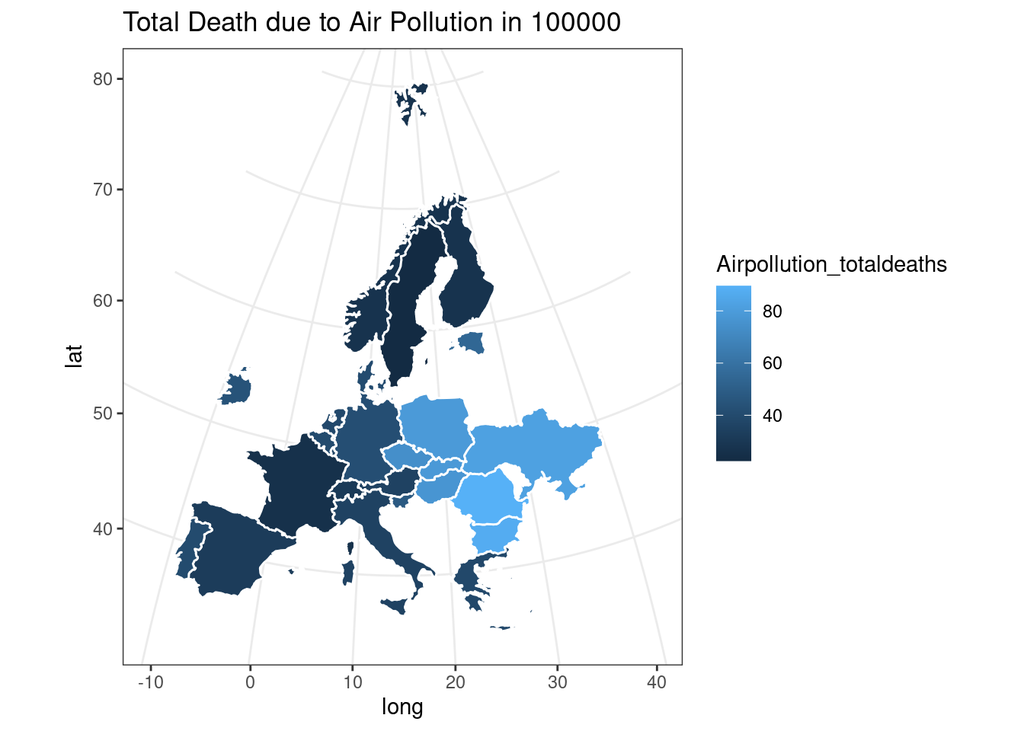

Fig. (5): map plot for 26 countries

```r
maniz <- data.frame(death_airPolution) |>
  select(Country, Year, Air.pollution..total...deaths.per.100.000.) |>
  group_by(Country, Air.pollution..total...deaths.per.100.000.) |>
  filter(Year==1990)
my_maniz <- maniz[,-2]
colnames(my_maniz)[1] <- "region"
colnames(my_maniz)[2] <- "Airpollution_totaldeaths"
my_vec <- c("Austria", "Belgium", "Czech Republic", "Denmark", "France", "Germany", "Hungary", "Ireland", "Luxembourg", "Netherlands", "Poland", "Slovakia", "Switzerland", "Romania", "Slovenia", "Spain", "Portugal", "Italy", "Ukraine", "Norway", "Sweden", "Finland", "Greece", "Bulgaria", "Liechtenstein", "Estonia")
my_maniz <- my_maniz[is.element(my_maniz$region, my_vec),]

map_thisdata <- map_data("world") ##ggplot2
new_mapdata <- left_join(map_thisdata, my_maniz, by="region")
new_mapdata <- new_mapdata |>
  filter(!is.na(new_mapdata$Airpollution_totaldeaths))

target <- ggplot(new_mapdata, aes(x = long, y = lat, group = group)) +
  geom_polygon(aes(fill = Airpollution_totaldeaths), color="white") +
  theme_bw() +
  coord_map("bonne",  lat0 = 50)  +
  ggtitle("Total Death due to Air Pollution in 100000")

target
```